# Link daily IDs of same visitor

Kang

2022-12-05

## Introduction

Since daily ID of a visitor update every day, so it is impossible to identify the track of different days of a visitor by the raw data directly. For example, a visitor A might have daily ID “A1” for the first day, while daily “A2” the next day. It doesn’t matter to the 日帰り visitors, but for the visitor who go to the mountain in the first day, stay overnight, and return back to mountain foot the next day, it matters. To do research on people’s behavior, it is critical to identify the behavior of each visitor. Here I tried to do that connection, **unfortunately, the result is not good**.

## A case

Firstly, let me show you my method with a simple case. Let’s pick out a user randomly first. Here we choose a visitor with daily ID of “974b58960e72f58a1d7a6a6d32b8f3f13c6c443be863a041af402088cb24fed14c549643c36917d3073e3108a5feed91” on July 1st.

The hour range of the visitor on that day is:

```r
range(gis.mobile.case.alllog$hour)
```

```
## [1]  0 21
```

That is perfect, since the hour range covers from the begining of the day to the night (21:00). There is no data after 21:00, so we can assume that the visitor takes a long rest after that time.

And the following map is his track on July 1st, the text show the hour of the track dots. We can see that the visitor starts from the south (maybe near Fujinomiya), go around the mountain to the north trail head, then climb the mountain. She or he arrives the mountain top at night.

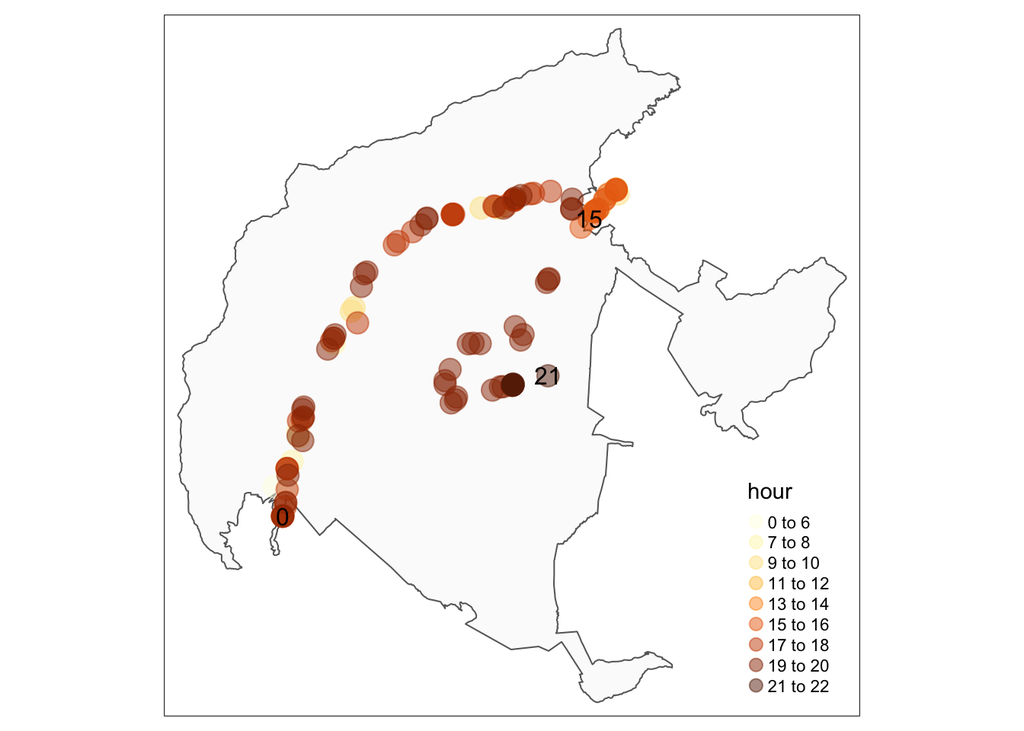

```r
tm_shape(nps.yamashizu) +
  tm_polygons(alpha = 0.1) +
  tm_shape(gis.mobile.case.alllog) +
  tm_dots(col = "hour", size = 1, alpha = 0.5) +
  tm_shape(gis.mobile.case.alllog %>%
             arrange(-hour) %>%
             group_by(hour) %>%
             mutate(rowid = row_number()) %>%
             ungroup() %>%
             subset(rowid == 1) %>%
             subset(hour %in% c(0, 15, 21))) +
  tm_text(text = "hour")
```

Then we get his latest log, which is near the mountain top:

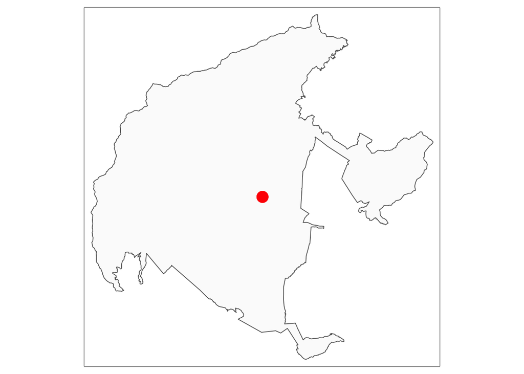

```r
tm_shape(nps.yamashizu) +
  tm_polygons(alpha = 0.1) +
  tm_shape(gis.mobile.case.lastlog) +
  tm_dots(col = "red", size = 1)
```

So, what does (s)he do the next day? Firstly, we pick out all the earliest movement within the mountain range the second day (July 2nd), showing in blue dots. Some blue dots are close to the red some are not, I assumed that the blue dots of the same visitor as the red dot should be close, so I made a buffer zone of 3000 meters (which was casually choosed though).

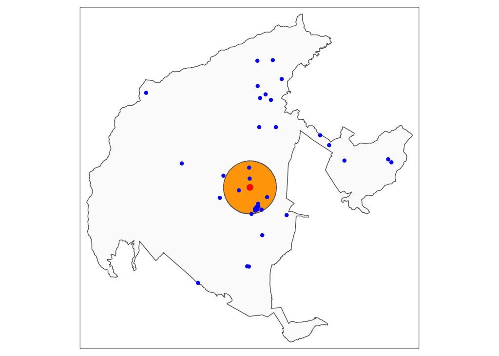

```r
tm_shape(nps.yamashizu) +
  tm_polygons(alpha = 0.1) +
  tm_shape(gis.mobile.case.lastlog.buff) +
  tm_polygons(col = "orange") +
  tm_shape(gis.mobile.secondday.earliest) +
  tm_dots(col = "blue", size = 0.1) +
  tm_shape(gis.mobile.case.lastlog) +
  tm_dots(col = "red", size = 0.3)
```

Then, I hope the one of the blue dots within the buffer zone belong to the same visitor as the red dot. I check the blue dots by: the target blue dot should be located with the buffer zone of the red dot (the orange circle), and it should have the same user information (like home prefecture, home city, work prefecture, work city, gender, etc.) with the red dot. That map shows the blue dots fullfille the conditions:

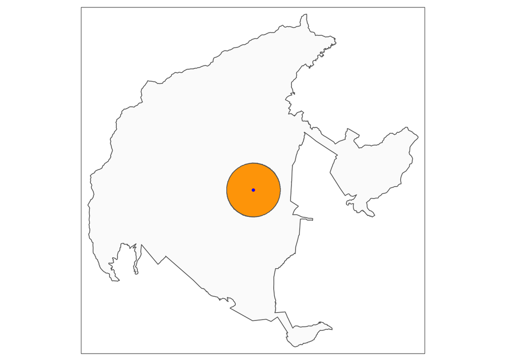

```r
tm_shape(nps.yamashizu) +
  tm_polygons(alpha = 0.1) +
  tm_shape(gis.mobile.case.lastlog.buff) +
  tm_polygons(col = "orange") +
  tm_shape(gis.mobile.case.lastlog) +
  tm_dots(col = "red", size = 0.05) +
  tm_shape(gis.mobile.secondday.earliest.inter.sameinfo) +
  tm_dots(col = "blue", size = 0.05)
```

We can not see it very clearly, but from the data, we know there are just one blue dot, which is perfect:

```r
rbind(
  gis.mobile.case.lastlog %>%
    mutate(source = "red dot") %>%
    select(source, dailyid, home_prefcode, home_citycode,
           workplace_prefcode, workplace_citycode, gender) %>%
    st_drop_geometry(),
  gis.mobile.secondday.earliest.inter.sameinfo %>%
    mutate(source = "blue dot") %>%
    select(source, dailyid, home_prefcode, home_citycode,
           workplace_prefcode, workplace_citycode, gender) %>%
    st_drop_geometry()
)
```

```
##         source
## 35396  red dot
## 35403  red dot
## 1     blue dot
##                                                                                                dailyid
## 35396 974b58960e72f58a1d7a6a6d32b8f3f13c6c443be863a041af402088cb24fed14c549643c36917d3073e3108a5feed91
## 35403 974b58960e72f58a1d7a6a6d32b8f3f13c6c443be863a041af402088cb24fed14c549643c36917d3073e3108a5feed91
## 1     d61cc25ad22bc147057379dac507c189ae80905b5cef9cd8ad5e39a1b3929657854c03069efe0645b7bfb952ef8884ff
##       home_prefcode home_citycode workplace_prefcode workplace_citycode gender
## 35396            22         22207                 22              22207
## 35403            22         22207                 22              22207
## 1                22         22207                 22              22207
```

Then I got the track of the target daily ID of the second day, and linked it to the track of the first day:

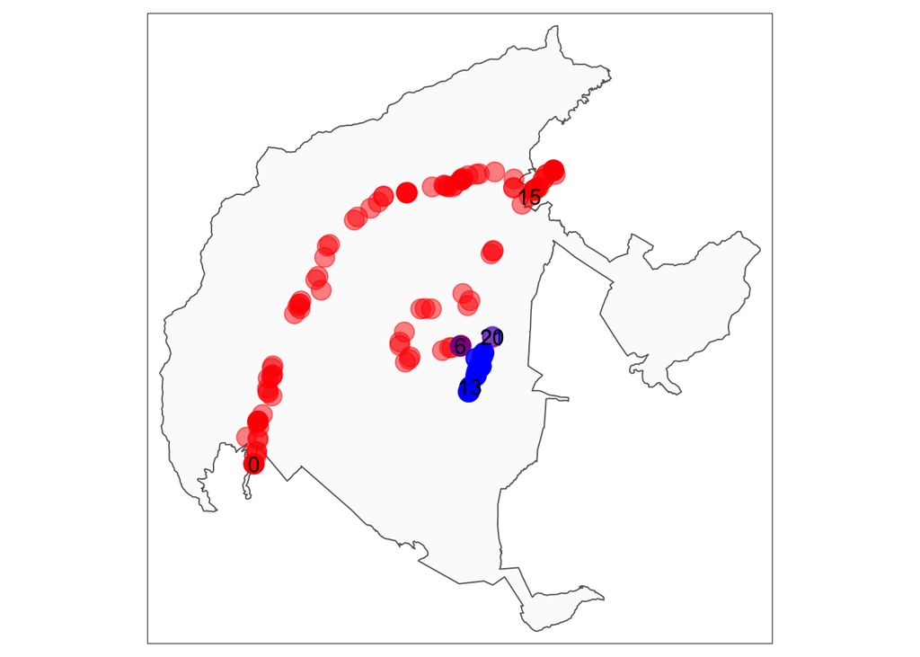

```r
tm_shape(nps.yamashizu) +
  tm_polygons(alpha = 0.1) +
  tm_shape(gis.mobile.case.alllog) +
  tm_dots(col = "red", size = 1, alpha = 0.5) +
  tm_shape(gis.mobile.case.alllog %>%
             arrange(-hour) %>%
             group_by(hour) %>%
             mutate(rowid = row_number()) %>%
             ungroup() %>%
             subset(rowid == 1) %>%
             subset(hour %in% c(0, 15, 21))) +
  tm_text(text = "hour") +
  tm_shape(gis.mobile.matchid) +
  tm_dots(col = "blue", size = 1, alpha = 0.5) +
  tm_shape(gis.mobile.matchid %>%
             arrange(-hour) %>%
             group_by(hour) %>%
             mutate(rowid = row_number()) %>%
             ungroup() %>%
             subset(rowid == 1) %>%
             subset(hour %in% c(6, 13, 20))) +
  tm_text(text = "hour")
```

Seems that (s)he stays in the mountain if the two daily IDs really belong to the same visitor. Let’s zoom in to see if it really make sense:

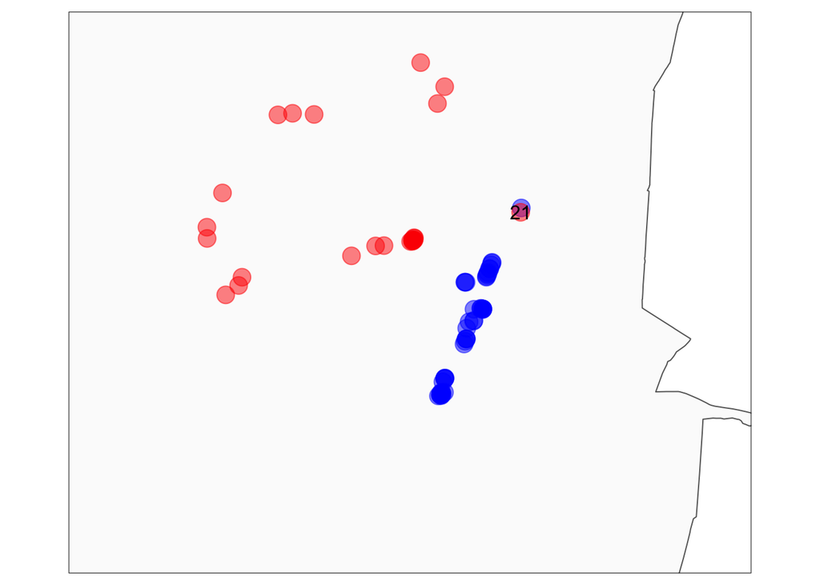

```r
tm_shape(nps.yamashizu,
         bbox = st_bbox(nps.yamashizu) * c(1.001, 1.003, 0.999, 0.996)) +
  tm_polygons(alpha = 0.1) +
  tm_shape(gis.mobile.matchid) +
  tm_dots(col = "blue", size = 1, alpha = 0.5) +
  tm_shape(gis.mobile.case.alllog) +
  tm_dots(col = "red", size = 1, alpha = 0.5) +
  tm_shape(gis.mobile.case.alllog %>%
             arrange(-hour) %>%
             group_by(hour) %>%
             mutate(rowid = row_number()) %>%
             ungroup() %>%
             subset(rowid == 1)) +
  tm_text(text = "hour")
```

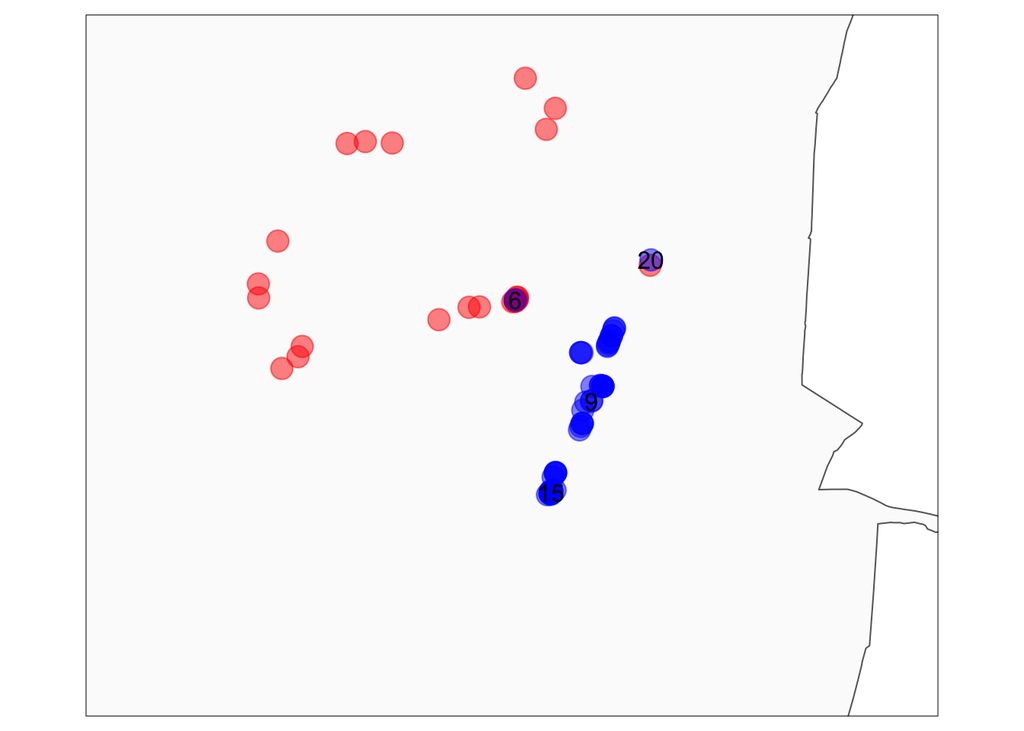

```r
tm_shape(nps.yamashizu,
         bbox = st_bbox(nps.yamashizu) * c(1.001, 1.003, 0.999, 0.996)) +
  tm_polygons(alpha = 0.1) +
  tm_shape(gis.mobile.case.alllog) +
  tm_dots(col = "red", size = 1, alpha = 0.5) +
  tm_shape(gis.mobile.matchid) +
  tm_dots(col = "blue", size = 1, alpha = 0.5) +
  tm_shape(gis.mobile.matchid %>%
             arrange(-hour) %>%
             group_by(hour) %>%
             mutate(rowid = row_number()) %>%
             ungroup() %>%
             subset(rowid == 1) %>%
             subset(hour %in% c(6, 9, 15, 20))) +
  tm_text(text = "hour")
```

So, if the two daily ID really belong to the same visitor, then (s)he goes to the right red dot at 21:00 of the first day, then starts from another dot in the left the next day, (s)he goes south, then returns back to north, and goes to the same location as the last dot of first day agan at the end of the second day.

All right, maybe (s)he wants to stay in the mountain for another day. That is not a problem.

With this case, I just want to show how the method works. I can give more cases that successfully link two daily IDs together as following figures.

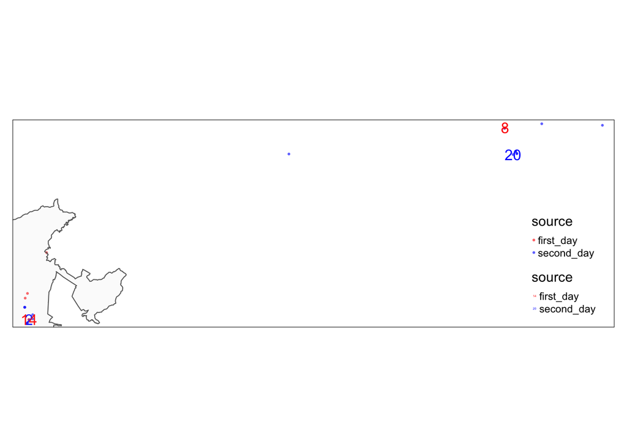

```r
GetCase("51494eaaf0c2e8f569742478b2eee74a23bb99390e88882ddc38ec47b1af872889777264922927d1f924ca50b64adbb7")
```

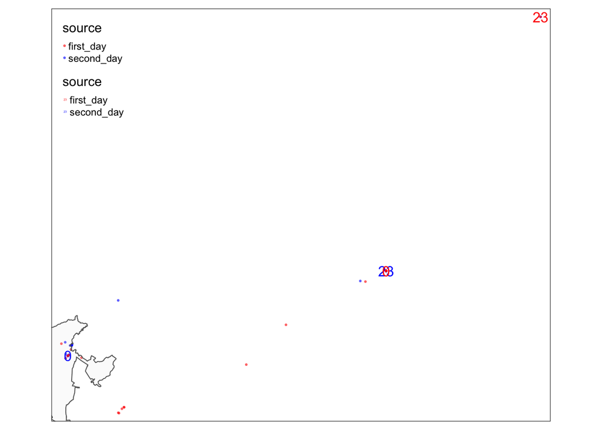

```r
GetCase("0f1b10a36395c36b8c3d4ff11c44a1ceb5780ec91dc468233d530548a1054150842d63e351d8d9c501945948df411b99")
```

Then I packed the code into a user-defined function in the following section, and further developed the function, to achieve: for a certain daily ID, how many daily IDs of the next day can be successully linked to it?